# Reproducible Research Project 2

imran

5/20/2022

## Impact of Severe Weather Events on Public Health and Economy in the United States

### Synopsis

Storms and other severe weather events can cause both public health and economic problems for communities and municipalities. Many severe events can result in fatalities, injuries, and property damage, and preventing such outcomes to the extent possible is a key concern.

This project involves exploring the U.S. National Oceanic and Atmospheric Administration’s (NOAA) storm database. This database tracks characteristics of major storms and weather events in the United States, including when and where they occur, as well as estimates of any fatalities, injuries, and property damage.

# Data Processing

I’m going to use The U.S. National Oceanic and Atmospheric Administration’s (NOAA) storm database which tracks characteristics of major storms and weather events in the United States. This dataset comes from the Internet.

Download file from the Internet:

```r
link = "http://d396qusza40orc.cloudfront.net/repdata%2Fdata%2FStormData.csv.bz2"
download.file(url = link, destfile = "StormData")
```

Read a file in table format

```r
StormData = read.csv(bzfile("StormData"),sep = ",",header=TRUE)
```

Property damage estimates were entered as actual dollar amounts (the variable PROPDMG). So I created a new variable PROPDMGEXP2 and assigned conditionally “K” = 1000, “M” = 1000000, “B” = 1000000000, in other cases 1. These variables are multiplied in the next step.

```r
table(StormData$PROPDMGEXP)
```

```
##
##             -      ?      +      0      1      2      3      4      5      6
## 465934      1      8      5    216     25     13      4      4     28      4
##      7      8      B      h      H      K      m      M
##      5      1     40      1      6 424665      7  11330
```

```r
StormData$PROPDMGEXP2 = 1
StormData$PROPDMGEXP2[which(StormData$PROPDMGEXP == "K")] = 1000
StormData$PROPDMGEXP2[which(StormData$PROPDMGEXP == "M" | StormData$PROPDMGEXP == "m")] = 1000000
StormData$PROPDMGEXP2[which(StormData$PROPDMGEXP == "B")] = 1000000000
```

```r
table(StormData$PROPDMGEXP2)
```

```
##
##      1   1000  1e+06  1e+09
## 466255 424665  11337     40
```

# Which types of events are most harmful to population health?

The first plot presents a Death toll by 15 Event type

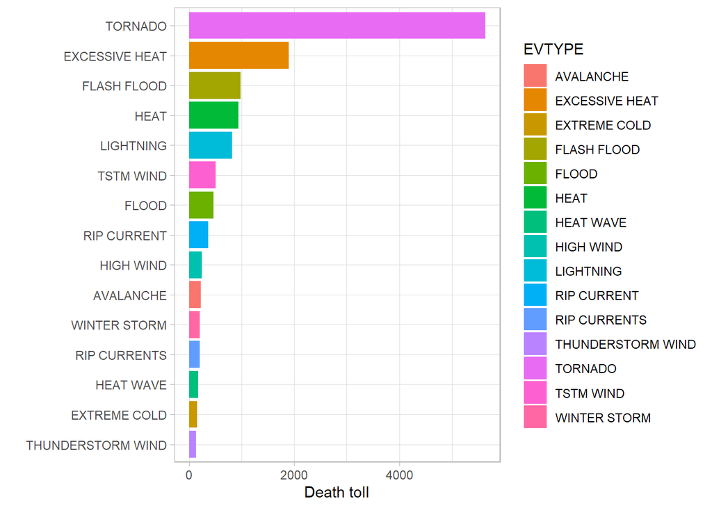

```r
StormData %>%
      select(FATALITIES, EVTYPE) %>%  group_by(EVTYPE) %>%  summarise(SumFATALITIES = sum(FATALITIES)) %>%
      top_n(n = 15, wt = SumFATALITIES) %>% ggplot(aes(y = SumFATALITIES, x = reorder(x = EVTYPE, X = SumFATALITIES), fill=EVTYPE))+
      geom_bar(stat = "identity", show.legend = TRUE) +  xlab(label = "") + ylab(label = "Death toll") + coord_flip() +  theme_light()
```

The second plot presents Injuries by 15 Event type

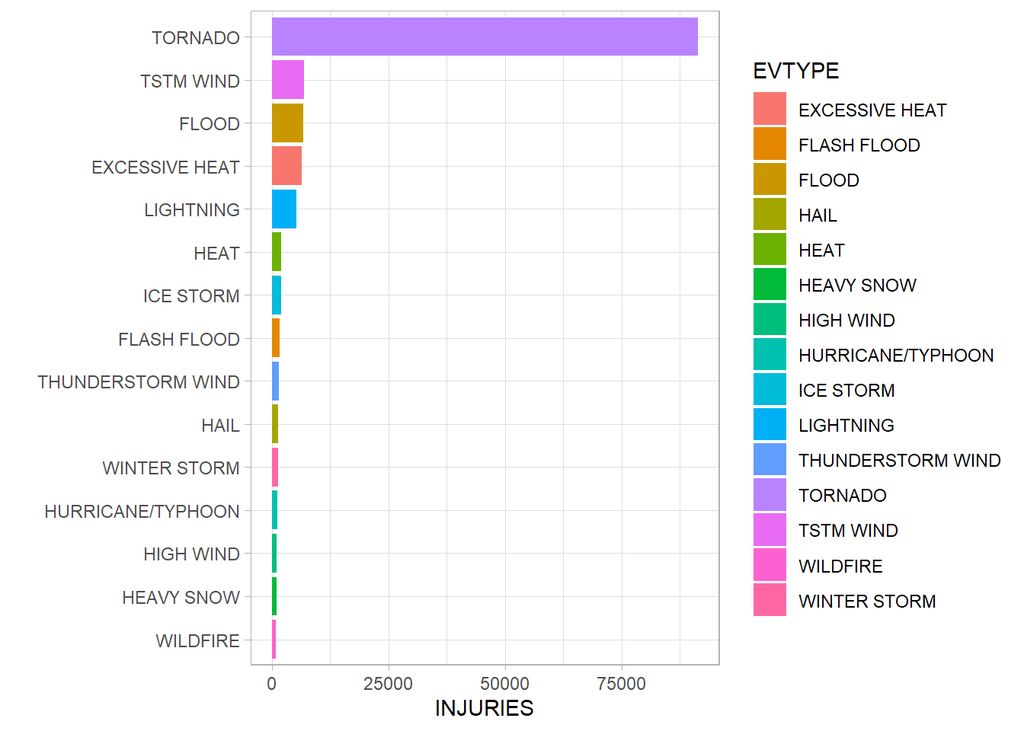

```r
StormData %>% select(INJURIES, EVTYPE) %>% group_by(EVTYPE) %>% summarise(SumINJURIES = sum(INJURIES)) %>%
      top_n(n = 15, wt = SumINJURIES) %>% ggplot(aes(y = SumINJURIES, x = reorder(x = EVTYPE, X = SumINJURIES), fill=EVTYPE))+
     geom_bar(stat = "identity", show.legend = TRUE) + xlab(label = "") + ylab(label = "INJURIES") +  coord_flip() +
      theme_light()
```

# Which types of events have the greatest economic consequences?

This plot shows Property damage estimates by 15 Event type

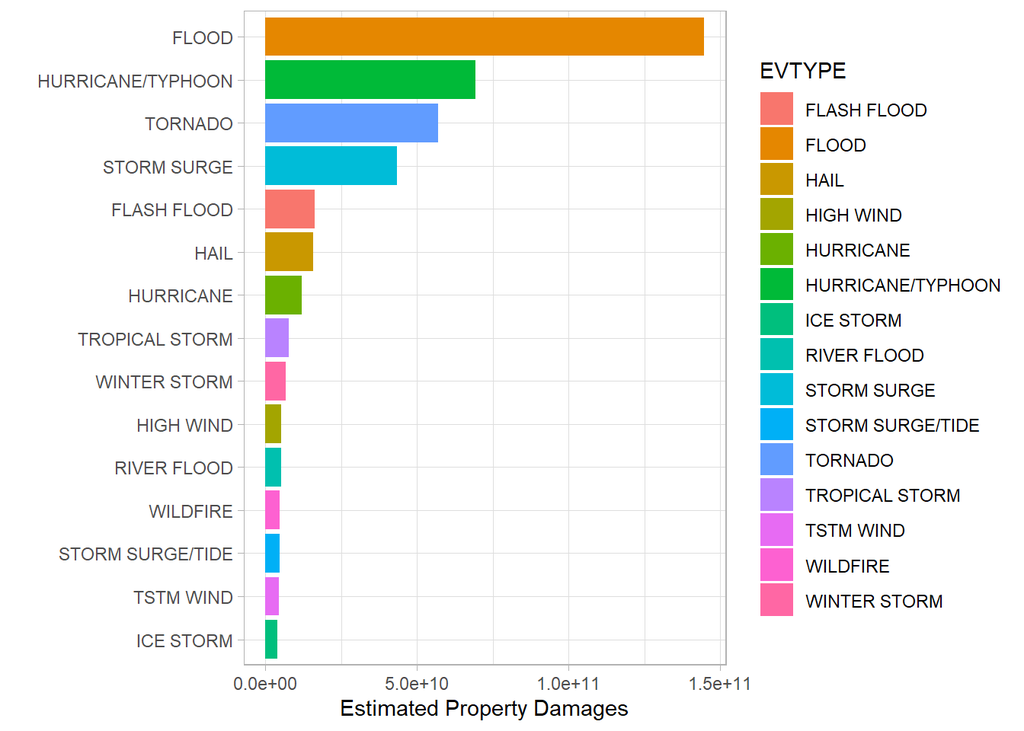

```r
StormData %>%  select(PROPDMG, PROPDMGEXP2, EVTYPE) %>% group_by(EVTYPE) %>% mutate(SumPROPDMGEXP = (PROPDMG * PROPDMGEXP2)) %>%
      summarise(SumPROPDMGEXP2 = sum(SumPROPDMGEXP)) %>% top_n(n = 15, wt = SumPROPDMGEXP2) %>%
      ggplot(aes(y = SumPROPDMGEXP2, x = reorder(x = EVTYPE, X = SumPROPDMGEXP2), fill=EVTYPE))+
      geom_bar(stat = "identity", show.legend = TRUE) + xlab(label = "") + ylab(label = "Estimated Property Damages") + coord_flip() +
      theme_light()
```

# Conclusion

#### From the analysis, flood has the greatest economic consequences and tornado is the most harmful to population health because it has the most death tolls and injuries.